# Link Prediction and Association Rules

# Introduction

Nestimate provides two complementary tools for discovering hidden structure in networks:

- **Link prediction** — which transitions are structurally expected but missing?
- **Association rules** — which activities co-occur within sessions?

Both integrate with `cograph::plot_simplicial()` via the `pathways()` method.

# Data

We use the bundled `group_regulation_long` dataset — self-regulated learning sequences from 2000 students with `Achiever` (High/Low) grouping.

```r
library(Nestimate)
data(group_regulation_long)
head(group_regulation_long)
```

| Actor | Achiever | Group | Course | Time | Action |
| --- | --- | --- | --- | --- | --- |
| 1 | High | 1 | A | 2025-01-01 10:27:07 | cohesion |
| 1 | High | 1 | A | 2025-01-01 10:35:20 | consensus |
| 1 | High | 1 | A | 2025-01-01 10:42:18 | discuss |
| 1 | High | 1 | A | 2025-01-01 10:50:00 | synthesis |
| 1 | High | 1 | A | 2025-01-01 10:52:25 | adapt |
| 1 | High | 1 | A | 2025-01-01 10:57:31 | consensus |

```r
net <- build_network(
  group_regulation_long, method = "relative",
  actor = "Actor", action = "Action", time = "Time"
)
net
```

```
#> Transition Network (relative probabilities) [directed]
#>   Weights: [0.001, 0.498]  |  mean: 0.116
#>
#>   Weight matrix:
#>              adapt cohesion consensus coregulate discuss emotion monitor  plan
#>   adapt      0.000    0.273     0.477      0.022   0.059   0.120   0.033 0.016
#>   cohesion   0.003    0.027     0.498      0.119   0.060   0.116   0.033 0.141
#>   consensus  0.005    0.015     0.082      0.188   0.188   0.073   0.047 0.396
#>   coregulate 0.016    0.036     0.135      0.023   0.274   0.172   0.086 0.239
#>   discuss    0.071    0.048     0.321      0.084   0.195   0.106   0.022 0.012
#>   emotion    0.002    0.325     0.320      0.034   0.102   0.077   0.036 0.100
#>   monitor    0.011    0.056     0.159      0.058   0.375   0.091   0.018 0.216
#>   plan       0.001    0.025     0.290      0.017   0.068   0.147   0.076 0.374
#>   synthesis  0.235    0.034     0.466      0.044   0.063   0.071   0.012 0.075
#>              synthesis
#>   adapt          0.000
#>   cohesion       0.004
#>   consensus      0.008
#>   coregulate     0.019
#>   discuss        0.141
#>   emotion        0.003
#>   monitor        0.016
#>   plan           0.002
#>   synthesis      0.000
#>
#>   Initial probabilities:
#>   consensus     0.214  ████████████████████████████████████████
#>   plan          0.204  ██████████████████████████████████████
#>   discuss       0.175  █████████████████████████████████
#>   emotion       0.151  ████████████████████████████
#>   monitor       0.144  ███████████████████████████
#>   cohesion      0.060  ███████████
#>   synthesis     0.019  ████
#>   coregulate    0.019  ████
#>   adapt         0.011  ██
```

# Link Prediction

## Running predictions

`predict_links()` runs six methods by default and ranks them by consensus:

```r
pred <- predict_links(net, exclude_existing = FALSE)
pred
```

```
#> Link Prediction  [directed | weighted | 9 nodes | 71 existing edges]
#>   Methods: common_neighbors, resource_allocation, adamic_adar, jaccard, preferential_attachment, katz
#>
#>   Top predicted links (consensus across 6 methods):
#>     1. discuss -> consensus  (avg rank: 5.5, agreed: 6/6)
#>     2. plan -> consensus  (avg rank: 5.5, agreed: 6/6)
#>     3. cohesion -> consensus  (avg rank: 6.0, agreed: 6/6)
#>     4. consensus -> cohesion  (avg rank: 6.2, agreed: 6/6)
#>     5. emotion -> consensus  (avg rank: 7.8, agreed: 6/6)
#>     6. consensus -> discuss  (avg rank: 10.5, agreed: 6/6)
#>     7. coregulate -> consensus  (avg rank: 12.0, agreed: 6/6)
#>     8. plan -> discuss  (avg rank: 13.3, agreed: 6/6)
#>     9. consensus -> plan  (avg rank: 13.8, agreed: 6/6)
#>     10. consensus -> coregulate  (avg rank: 14.0, agreed: 6/6)
#>     ... and 62 more predictions
```

The consensus ranking averages each pair’s rank across all methods — pairs consistently ranked high are the strongest predictions:

```r
head(pred$consensus, 10)
```

| from | to | avg_rank | n_methods | consensus_rank |
| --- | --- | --- | --- | --- |
| discuss | consensus | 5.500000 | 6 | 1 |
| plan | consensus | 5.500000 | 6 | 2 |
| cohesion | consensus | 6.000000 | 6 | 3 |
| consensus | cohesion | 6.166667 | 6 | 4 |
| emotion | consensus | 7.833333 | 6 | 5 |
| consensus | discuss | 10.500000 | 6 | 6 |
| coregulate | consensus | 12.000000 | 6 | 7 |
| plan | discuss | 13.333333 | 6 | 8 |
| consensus | plan | 13.833333 | 6 | 9 |
| consensus | coregulate | 14.000000 | 6 | 10 |

## Choosing a method

You can also run a single method:

```r
pred_katz <- predict_links(net, methods = "katz", exclude_existing = FALSE)
pred_katz
```

```
#> Link Prediction  [directed | weighted | 9 nodes | 71 existing edges]
#>   Methods: katz
#>
#>   Top predicted links (katz):
#>     1. discuss -> cohesion  (score: 1.0631)
#>     2. emotion -> cohesion  (score: 1.0631)
#>     3. monitor -> cohesion  (score: 1.0631)
#>     4. cohesion -> consensus  (score: 1.0631)
#>     5. discuss -> consensus  (score: 1.0631)
#>     6. emotion -> consensus  (score: 1.0631)
#>     7. monitor -> consensus  (score: 1.0631)
#>     8. cohesion -> coregulate  (score: 1.0631)
#>     9. emotion -> coregulate  (score: 1.0631)
#>     10. cohesion -> discuss  (score: 1.0631)
#>     ... and 62 more predictions
```

| Method | Idea | Best for |
| --- | --- | --- |
| `common_neighbors` | Shared out- and in-neighbors | Dense local structure |
| `resource_allocation` | Shared neighbors weighted by 1/degree | Hub-dominated networks |
| `adamic_adar` | Shared neighbors weighted by 1/log(degree) | General-purpose |
| `jaccard` | Shared / union neighbors | Cross-network comparison |
| `preferential_attachment` | out-degree(i) x in-degree(j) | Scale-free networks |
| `katz` | All paths weighted by length | Global structure |

## Sparse networks

Link prediction is most useful when edges are missing. Threshold the network to create gaps, then predict what’s missing:

```r
net_sparse <- build_network(
  group_regulation_long, method = "relative",
  actor = "Actor", action = "Action", time = "Time",
  threshold = 0.05
)
pred_sparse <- predict_links(net_sparse, methods = "resource_allocation")
pred_sparse
```

```
#> Link Prediction  [directed | weighted | 9 nodes | 42 existing edges]
#>   Methods: resource_allocation
#>
#>   Top predicted links (resource_allocation):
#>     1. consensus -> cohesion  (score: 0.0417)
#>     2. discuss -> plan  (score: 0.0360)
#>     3. emotion -> adapt  (score: 0.0264)
#>     4. consensus -> adapt  (score: 0.0239)
#>     5. plan -> coregulate  (score: 0.0231)
#>     6. discuss -> cohesion  (score: 0.0219)
#>     7. plan -> cohesion  (score: 0.0200)
#>     8. synthesis -> cohesion  (score: 0.0183)
#>     9. cohesion -> synthesis  (score: 0.0183)
#>     10. cohesion -> adapt  (score: 0.0182)
#>     ... and 20 more predictions
```

## Evaluating predictions

Use the full network’s edges as ground truth to evaluate predictions from the sparse network:

```r
true_edges <- extract_edges(net)
pred_eval <- predict_links(net_sparse, exclude_existing = FALSE)
evaluate_links(pred_eval, true_edges[, c("from", "to")], k = c(3, 5, 10))
```

| method | auc | average_precision | precision_at_3 | precision_at_5 | precision_at_10 |
| --- | --- | --- | --- | --- | --- |
| common_neighbors | NA | 1 | 1 | 1 | 1 |
| resource_allocation | NA | 1 | 1 | 1 | 1 |
| adamic_adar | NA | 1 | 1 | 1 | 1 |
| jaccard | NA | 1 | 1 | 1 | 1 |
| preferential_attachment | NA | 1 | 1 | 1 | 1 |
| katz | NA | 1 | 1 | 1 | 1 |

## Per-group predictions

Build separate networks per group and predict within each:

```r
nets <- build_network(
  group_regulation_long, method = "relative",
  actor = "Actor", action = "Action", time = "Time",
  group = "Achiever", threshold = 0.05
)
lapply(nets, function(g) predict_links(g, methods = "katz", top_n = 3))
```

```
#> $High
#> Link Prediction  [directed | weighted | 9 nodes | 38 existing edges]
#>   Methods: katz
#>
#>   Top predicted links (katz):
#>     1. discuss -> plan  (score: 1.4836)
#>     2. cohesion -> discuss  (score: 1.1532)
#>     3. synthesis -> discuss  (score: 0.9990)
#>
#> $Low
#> Link Prediction  [directed | weighted | 9 nodes | 44 existing edges]
#>   Methods: katz
#>
#>   Top predicted links (katz):
#>     1. discuss -> plan  (score: 1.1003)
#>     2. synthesis -> plan  (score: 0.9448)
#>     3. adapt -> plan  (score: 0.8393)
```

## Extracting pathways

`pathways()` converts predictions into strings for `cograph::plot_simplicial()`. With `evidence = TRUE` (default), each predicted edge is enriched with common neighbors that structurally bridge source to target:

```r
pathways(pred_sparse, top = 5, evidence = TRUE)
```

```
#> [1] "consensus emotion -> cohesion"
#> [2] "discuss consensus coregulate emotion -> plan"
#> [3] "emotion discuss -> adapt"
#> [4] "consensus discuss -> adapt"
#> [5] "plan consensus discuss monitor -> coregulate"
```

`"A cn1 cn2 -> B"` means: A is predicted to connect to B, with cn1 and cn2 as the bridging nodes. Without evidence:

```r
pathways(pred_sparse, top = 5, evidence = FALSE)
```

```
#> [1] "consensus -> cohesion" "discuss -> plan"       "emotion -> adapt"
#> [4] "consensus -> adapt"    "plan -> coregulate"
```

# Association Rules

## Basic usage

`association_rules()` treats each sequence as a basket of its unique states, then finds co-occurrence patterns via Apriori:

```r
rules <- association_rules(net, min_support = 0.3,
                           min_confidence = 0.5, min_lift = 1.0)
rules
```

```
#> Association Rules  [640 rules | 8 items | 2000 transactions]
#>   Support >= 0.30  |  Confidence >= 0.50  |  Lift >= 1.00
#>
#>   Top rules (by lift):
#>     1. cohesion, coregulate -> discuss, emotion, plan  (sup=0.302 conf=0.772 lift=1.36)
#>     2. discuss, emotion, plan -> cohesion, coregulate  (sup=0.302 conf=0.534 lift=1.36)
#>     3. cohesion, coregulate -> consensus, discuss, emotion  (sup=0.316 conf=0.807 lift=1.35)
#>     4. consensus, discuss, emotion -> cohesion, coregulate  (sup=0.316 conf=0.529 lift=1.35)
#>     5. cohesion, consensus, coregulate -> discuss, emotion  (sup=0.316 conf=0.827 lift=1.35)
#>     6. discuss, emotion -> cohesion, consensus, coregulate  (sup=0.316 conf=0.516 lift=1.35)
#>     7. cohesion, coregulate, plan -> discuss, emotion  (sup=0.302 conf=0.826 lift=1.35)
#>     8. cohesion, discuss, plan -> coregulate, emotion  (sup=0.302 conf=0.672 lift=1.35)
#>     9. coregulate, emotion -> cohesion, discuss, plan  (sup=0.302 conf=0.606 lift=1.35)
#>     10. cohesion, coregulate -> discuss, emotion  (sup=0.320 conf=0.817 lift=1.34)
#>     ... and 630 more rules
```

## Understanding the output

```r
summary(rules)
```

```
#>                             antecedent                           consequent
#>                    cohesion,coregulate                 discuss,emotion,plan
#>                   discuss,emotion,plan                  cohesion,coregulate
#>                    cohesion,coregulate            consensus,discuss,emotion
#>              consensus,discuss,emotion                  cohesion,coregulate
#>          cohesion,consensus,coregulate                      discuss,emotion
#>                        discuss,emotion        cohesion,consensus,coregulate
#>               cohesion,coregulate,plan                      discuss,emotion
#>                  cohesion,discuss,plan                   coregulate,emotion
#>                     coregulate,emotion                cohesion,discuss,plan
#>                    cohesion,coregulate                      discuss,emotion
#>                        discuss,emotion                  cohesion,coregulate
#>             cohesion,consensus,discuss                   coregulate,emotion
#>                     coregulate,emotion           cohesion,consensus,discuss
#>             coregulate,discuss,emotion                        cohesion,plan
#>                          cohesion,plan           coregulate,discuss,emotion
#>             coregulate,discuss,emotion                   cohesion,consensus
#>                     cohesion,consensus           coregulate,discuss,emotion
#>                coregulate,emotion,plan                     cohesion,discuss
#>                       cohesion,discuss              coregulate,emotion,plan
#>           consensus,coregulate,emotion                     cohesion,discuss
#>                       cohesion,discuss         consensus,coregulate,emotion
#>                     coregulate,emotion              cohesion,consensus,plan
#>                cohesion,consensus,plan                   coregulate,emotion
#>           consensus,coregulate,emotion                        cohesion,plan
#>                          cohesion,plan         consensus,coregulate,emotion
#>                coregulate,emotion,plan                   cohesion,consensus
#>                     cohesion,consensus              coregulate,emotion,plan
#>                       cohesion,discuss                   coregulate,emotion
#>                     coregulate,emotion                     cohesion,discuss
#>                    cohesion,coregulate               consensus,emotion,plan
#>                 consensus,emotion,plan                  cohesion,coregulate
#>                     coregulate,emotion                        cohesion,plan
#>                          cohesion,plan                   coregulate,emotion
#>                     cohesion,consensus                 discuss,emotion,plan
#>                   discuss,emotion,plan                   cohesion,consensus
#>               cohesion,coregulate,plan                    consensus,emotion
#>          cohesion,consensus,coregulate                         emotion,plan
#>                cohesion,consensus,plan                      discuss,emotion
#>                        discuss,emotion              cohesion,consensus,plan
```

[output cut: 1227 more lines]

```
#>   0.5140     0.5984 1.0415     1.0594  1028
#>   0.8145     0.9482 1.0391     1.6890  1629
#>   0.8145     0.8926 1.0391     1.3129  1629
#>   0.7470     0.9474 1.0382     1.6625  1494
#>   0.7470     0.8186 1.0382     1.1661  1494
#>   0.4710     0.9467 1.0375     1.6427   942
#>   0.4710     0.5162 1.0375     1.0386   942
#>   0.6970     0.9406 1.0308     1.4736  1394
#>   0.6970     0.7638 1.0308     1.0967  1394
#>   0.4865     0.9392 1.0292     1.4389   973
#>   0.4865     0.5332 1.0292     1.0325   973
#>   0.5390     0.9382 1.0282     1.4160  1078
#>   0.5390     0.5907 1.0282     1.0395  1078
#>   0.6885     0.8732 1.0165     1.1118  1377
#>   0.6885     0.8015 1.0165     1.0656  1377
```

| Metric | Meaning |
| --- | --- |
| **Support** | P(A and B) — how common is this pattern? |
| **Confidence** | P(B given A) — how reliable is this implication? |
| **Lift** | > 1 = positive association, < 1 = negative |
| **Conviction** | Departure from independence (higher = stronger) |

## Adjusting thresholds

```r
rules_broad  <- association_rules(net, min_support = 0.1,
                                  min_confidence = 0.3, min_lift = 0)
rules_strict <- association_rules(net, min_support = 0.5,
                                  min_confidence = 0.8, min_lift = 1.0)
data.frame(
  Setting = c("Broad (sup>=0.1, conf>=0.3)", "Strict (sup>=0.5, conf>=0.8, lift>=1)"),
  Rules   = c(rules_broad$n_rules, rules_strict$n_rules)
)
```

| Setting | Rules |
| --- | --- |
| Broad (sup>=0.1, conf>=0.3) | 3043 |
| Strict (sup>=0.5, conf>=0.8, lift>=1) | 44 |

## Per-group rules

```r
nets <- build_network(
  group_regulation_long, method = "relative",
  actor = "Actor", action = "Action", time = "Time",
  group = "Achiever"
)
lapply(nets, function(g) {
  association_rules(g, min_support = 0.3, min_confidence = 0.5, min_lift = 1.0)
})
```

```
#> $High
#> Association Rules  [587 rules | 7 items | 1000 transactions]
#>   Support >= 0.30  |  Confidence >= 0.50  |  Lift >= 1.00
#>
#>   Top rules (by lift):
#>     1. cohesion, coregulate -> discuss, emotion, plan  (sup=0.322 conf=0.809 lift=1.36)
#>     2. discuss, emotion, plan -> cohesion, coregulate  (sup=0.322 conf=0.541 lift=1.36)
#>     3. cohesion, discuss, plan -> coregulate, emotion  (sup=0.322 conf=0.675 lift=1.35)
#>     4. coregulate, emotion -> cohesion, discuss, plan  (sup=0.322 conf=0.643 lift=1.35)
#>     5. cohesion, consensus, coregulate -> discuss, emotion  (sup=0.335 conf=0.861 lift=1.33)
#>     6. discuss, emotion -> cohesion, consensus, coregulate  (sup=0.335 conf=0.518 lift=1.33)
#>     7. cohesion, coregulate, plan -> discuss, emotion  (sup=0.322 conf=0.861 lift=1.33)
#>     8. cohesion, coregulate -> consensus, discuss, emotion  (sup=0.335 conf=0.842 lift=1.32)
#>     9. consensus, discuss, emotion -> cohesion, coregulate  (sup=0.335 conf=0.527 lift=1.32)
#>     10. coregulate, discuss, emotion -> cohesion, plan  (sup=0.322 conf=0.714 lift=1.32)
#>     ... and 577 more rules
#>
#> $Low
#> Association Rules  [657 rules | 9 items | 1000 transactions]
#>   Support >= 0.30  |  Confidence >= 0.50  |  Lift >= 1.00
#>
#>   Top rules (by lift):
#>     1. cohesion, coregulate -> discuss, emotion  (sup=0.301 conf=0.784 lift=1.36)
#>     2. discuss, emotion -> cohesion, coregulate  (sup=0.301 conf=0.523 lift=1.36)
#>     3. coregulate, emotion, plan -> cohesion, consensus  (sup=0.309 conf=0.673 lift=1.34)
#>     4. cohesion, consensus -> coregulate, emotion, plan  (sup=0.309 conf=0.614 lift=1.34)
#>     5. cohesion, consensus, plan -> coregulate, emotion  (sup=0.309 conf=0.660 lift=1.33)
#>     6. coregulate, emotion -> cohesion, consensus, plan  (sup=0.309 conf=0.623 lift=1.33)
#>     7. consensus, coregulate, emotion -> cohesion, plan  (sup=0.309 conf=0.642 lift=1.32)
#>     8. cohesion, plan -> consensus, coregulate, emotion  (sup=0.309 conf=0.636 lift=1.32)
#>     9. cohesion, discuss -> coregulate, emotion  (sup=0.301 conf=0.652 lift=1.31)
#>     10. coregulate, emotion -> cohesion, discuss  (sup=0.301 conf=0.607 lift=1.31)
#>     ... and 647 more rules
```

Rules unique to one group suggest activity combinations associated with that group’s outcomes.

## Plotting rules

Support vs confidence scatter, with point size and color encoding lift:

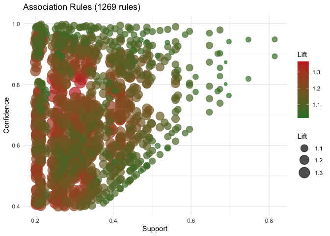

```r
rules <- association_rules(net, min_support = 0.2,
                           min_confidence = 0.4, min_lift = 1.0)
if (rules$n_rules > 0) plot(rules)
```

## Extracting pathways

Each rule `{A, B} => {C}` becomes `"A B -> C"`:

```r
rules <- association_rules(net, min_support = 0.3,
                           min_confidence = 0.5, min_lift = 1.0)
pathways(rules)
```

```
#>   [1] "cohesion coregulate -> discuss emotion plan"
#>   [2] "discuss emotion plan -> cohesion coregulate"
#>   [3] "cohesion coregulate -> consensus discuss emotion"
#>   [4] "consensus discuss emotion -> cohesion coregulate"
#>   [5] "cohesion consensus coregulate -> discuss emotion"
#>   [6] "discuss emotion -> cohesion consensus coregulate"
#>   [7] "cohesion coregulate plan -> discuss emotion"
#>   [8] "cohesion discuss plan -> coregulate emotion"
#>   [9] "coregulate emotion -> cohesion discuss plan"
#>  [10] "cohesion coregulate -> discuss emotion"
#>  [11] "discuss emotion -> cohesion coregulate"
#>  [12] "cohesion consensus discuss -> coregulate emotion"
#>  [13] "coregulate emotion -> cohesion consensus discuss"
#>  [14] "coregulate discuss emotion -> cohesion plan"
#>  [15] "cohesion plan -> coregulate discuss emotion"
```

[output cut: 625 more lines]

Filter to the strongest:

```r
pathways(rules, top = 5, min_lift = 1.2)
```

```
#> [1] "cohesion coregulate -> discuss emotion plan"
#> [2] "discuss emotion plan -> cohesion coregulate"
#> [3] "cohesion coregulate -> consensus discuss emotion"
#> [4] "consensus discuss emotion -> cohesion coregulate"
#> [5] "cohesion consensus coregulate -> discuss emotion"
```

## Other input formats

Transaction list:

```r
transactions <- list(
  c("plan", "discuss", "execute"),
  c("plan", "research", "analyze"),
  c("discuss", "execute", "reflect"),
  c("plan", "discuss", "execute", "reflect"),
  c("research", "analyze", "reflect")
)
association_rules(transactions, min_support = 0.3,
                  min_confidence = 0.5, min_lift = 0)
```

```
#> Association Rules  [24 rules | 6 items | 5 transactions]
#>   Support >= 0.30  |  Confidence >= 0.50  |  Lift >= 0.00
#>
#>   Top rules (by lift):
#>     1. analyze -> research  (sup=0.400 conf=1.000 lift=2.50)
#>     2. research -> analyze  (sup=0.400 conf=1.000 lift=2.50)
#>     3. discuss -> execute  (sup=0.600 conf=1.000 lift=1.67)
#>     4. execute -> discuss  (sup=0.600 conf=1.000 lift=1.67)
#>     5. discuss, plan -> execute  (sup=0.400 conf=1.000 lift=1.67)
#>     6. execute, plan -> discuss  (sup=0.400 conf=1.000 lift=1.67)
#>     7. discuss, reflect -> execute  (sup=0.400 conf=1.000 lift=1.67)
#>     8. execute, reflect -> discuss  (sup=0.400 conf=1.000 lift=1.67)
#>     9. discuss -> execute, plan  (sup=0.400 conf=0.667 lift=1.67)
#>     10. execute -> discuss, plan  (sup=0.400 conf=0.667 lift=1.67)
#>     ... and 14 more rules
```

Binary matrix:

```r
mat <- matrix(c(
  1, 1, 1, 0, 0,
  1, 0, 0, 1, 1,
  0, 1, 1, 0, 1,
  1, 1, 1, 1, 0,
  1, 0, 1, 0, 1
), nrow = 5, byrow = TRUE)
colnames(mat) <- c("plan", "discuss", "execute", "research", "reflect")
association_rules(mat, min_support = 0.3, min_confidence = 0.5, min_lift = 0)
```

```
#> Association Rules  [18 rules | 5 items | 5 transactions]
#>   Support >= 0.30  |  Confidence >= 0.50  |  Lift >= 0.00
#>
#>   Top rules (by lift):
#>     1. discuss -> execute  (sup=0.600 conf=1.000 lift=1.25)
#>     2. execute -> discuss  (sup=0.600 conf=0.750 lift=1.25)
#>     3. research -> plan  (sup=0.400 conf=1.000 lift=1.25)
#>     4. plan, discuss -> execute  (sup=0.400 conf=1.000 lift=1.25)
#>     5. plan -> research  (sup=0.400 conf=0.500 lift=1.25)
#>     6. execute -> plan, discuss  (sup=0.400 conf=0.500 lift=1.25)
#>     7. discuss -> plan, execute  (sup=0.400 conf=0.667 lift=1.11)
#>     8. plan, execute -> discuss  (sup=0.400 conf=0.667 lift=1.11)
#>     9. plan -> execute  (sup=0.600 conf=0.750 lift=0.94)
#>     10. execute -> plan  (sup=0.600 conf=0.750 lift=0.94)
#>     ... and 8 more rules
```

# Simplicial Visualization

Both link predictions and association rules integrate with `cograph::plot_simplicial()` for higher-order visualization. Each pathway becomes a blob grouping source nodes, pointing to the target.

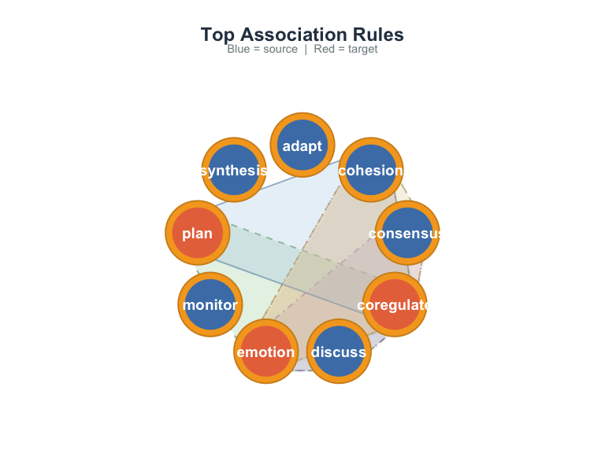

```r
library(cograph)
net_sparse <- build_network(
  group_regulation_long, method = "relative",
  actor = "Actor", action = "Action", time = "Time",
  threshold = 0.05
)

# Association rules as simplicial blobs
rules <- association_rules(net_sparse, min_support = 0.3,
                           min_confidence = 0.5, min_lift = 1.0)
plot_simplicial(net_sparse, pathways(rules, top = 5),
                title = "Top Association Rules")
```

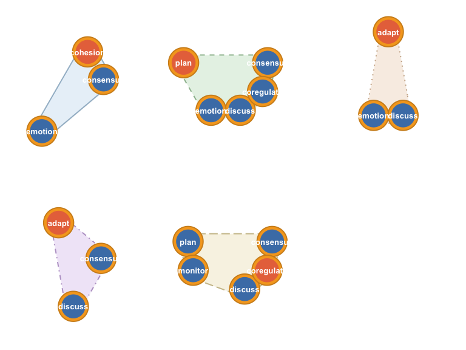

```r
# Predicted links with structural evidence
pred <- predict_links(net_sparse, methods = "resource_allocation")
plot_simplicial(net_sparse, pathways(pred, top = 5, evidence = TRUE),
                title = "Predicted Links with Evidence",
                dismantled = TRUE)
```

The **dismantled** view shows each pathway in its own panel.

Both styles work:

```r
# Via pathways() (works with any cograph version)
plot_simplicial(net, pathways(rules, top = 5))
plot_simplicial(net, pathways(pred, top = 5))

# Direct pass (requires cograph >= 1.9.0)
plot_simplicial(net, rules)
plot_simplicial(net, pred)
```